# Diagnosing stat-level model

Justin, Natalia

Sep 14, 2020

## Goal

Double-check the analysis in`v1.Rmd`, which produce ROC curves that seem too good to be true.

## Obtain data

Obtain state level data.

```r
## Setup
lags = 28
n_ahead = 21 ## 28
threshold = 0.25
geo_type = "state" ## or "county"
response = "confirmed_7dav_incidence_prop"
fn_response = response_diff_avg_1week_min20
fn_response_name = "response_diff_avg_1week_min20"
slope = TRUE
onset = FALSE

## Read in data once
data_sources = c("indicator-combination",
                 "fb-survey")
signals = c("confirmed_7dav_incidence_prop",
            "smoothed_hh_cmnty_cli")
start_day = as.Date("2020-05-01")
end_day = as.Date("2020-08-30")
signals = data.frame(data_sources = data_sources, signals = signals)
suppressMessages({
  mat = covidcast_signals(signals,
                          start_day = start_day, end_day = end_day, geo_type = geo_type)
})
mat <- mat %>% select(geo_value, time_value, signal, data_source, value)
## save(mat, file=file.path(outputdir, "new-state-data.Rdata"))
## load(file=file.path(outputdir, "new-state-data.Rdata"))

## Form the y|X matrix
df_model <- ready_to_model(mat, lags, n_ahead, response, slope, fn_response, threshold, onset)
df_model %>% names() %>% print()
```

```
##  [1] "geo_value"
##  [2] "time_value"
##  [3] "feature_lag0_confirmed_7dav_incidence_prop_indicator-combination"
##  [4] "feature_lag0_smoothed_hh_cmnty_cli_fb-survey"
##  [5] "feature_lag1_confirmed_7dav_incidence_prop_indicator-combination"
##  [6] "feature_lag1_smoothed_hh_cmnty_cli_fb-survey"
##  [7] "feature_lag2_confirmed_7dav_incidence_prop_indicator-combination"
##  [8] "feature_lag2_smoothed_hh_cmnty_cli_fb-survey"
##  [9] "feature_lag3_confirmed_7dav_incidence_prop_indicator-combination"
## [10] "feature_lag3_smoothed_hh_cmnty_cli_fb-survey"
## [11] "feature_lag4_confirmed_7dav_incidence_prop_indicator-combination"
## [12] "feature_lag4_smoothed_hh_cmnty_cli_fb-survey"
## [13] "feature_lag5_confirmed_7dav_incidence_prop_indicator-combination"
## [14] "feature_lag5_smoothed_hh_cmnty_cli_fb-survey"
## [15] "feature_slope4_confirmed_7dav_incidence_prop_indicator-combination"
```

[output cut: 18 more lines]

## Main code

This is the barebones code for doing logistic lasso prediction on state level data. The reader should double-check this code for any mistakes.

```r
## Now take one split
geo_split_seed = 100
geo_cv_split_seed = 10000
source('helpers.r')
splitted <- sample_split_geo(df_model, pct_test = 0.3, seed = geo_split_seed)

## See the distribution of 1's and 0's
df_model %>% select(resp) %>% table() %>% print()
```

```
## .
##    0    1
## 3375  407
```

```r
splitted$df_train %>% select(resp) %>% table() %>% print()
```

```
## .
##    0    1
## 2489  249
```

```r
splitted$df_test %>% select(resp) %>% table() %>% print()
```

```
## .
##   0   1
## 886 158
```

```r
nfold = 5
foldid <- make_foldid_geo(splitted$df_train, nfold = nfold, geo_cv_split_seed)
for(ifold in 1:5){
  splitted$df_train[which(foldid==ifold),] %>% select(resp) %>% table() %>% print()
}
```

```
## .
##   0   1
## 429  89
## .
##   0   1
## 556  36
## .
##   0   1
## 561  31
## .
##   0   1
## 485  33
## .
##   0   1
## 458  60
```

```r
## If you don't want FB features, do this:
## df_train = splitted$df_train %>% select(geo_value, time_value, resp, contains(response))
## df_test = splitted$df_test %>% select(geo_value, time_value, resp, contains(response))

## If you DO want FB features, do this:
df_train = splitted$df_train
df_test = splitted$df_test

## Main part of the lasso fitting and predicting
fit_lasso <- cv.glmnet(x = as.matrix(df_train %>% select(-geo_value, -time_value, -resp)),
                       y = df_train$resp,
                       family = "binomial",
                       alpha = 1,
                       foldid = foldid,
                       nfold = nfold)

## See the fitted model
coef(fit_lasso, s = "lambda.min") %>% print()
```

```
## 31 x 1 sparse Matrix of class "dgCMatrix"
##                                                                                1
## (Intercept)                                                          -5.67772230
## feature_lag0_confirmed_7dav_incidence_prop_indicator-combination      0.03965767
## feature_lag0_smoothed_hh_cmnty_cli_fb-survey                          0.09019762
## feature_lag1_confirmed_7dav_incidence_prop_indicator-combination      .
## feature_lag1_smoothed_hh_cmnty_cli_fb-survey                          .
## feature_lag2_confirmed_7dav_incidence_prop_indicator-combination      .
## feature_lag2_smoothed_hh_cmnty_cli_fb-survey                          .
## feature_lag3_confirmed_7dav_incidence_prop_indicator-combination      .
## feature_lag3_smoothed_hh_cmnty_cli_fb-survey                          .
## feature_lag4_confirmed_7dav_incidence_prop_indicator-combination      .
## feature_lag4_smoothed_hh_cmnty_cli_fb-survey                          .
## feature_lag5_confirmed_7dav_incidence_prop_indicator-combination      .
## feature_lag5_smoothed_hh_cmnty_cli_fb-survey                          .
## feature_slope4_confirmed_7dav_incidence_prop_indicator-combination    0.40599921
## feature_slope4_smoothed_hh_cmnty_cli_fb-survey                        2.99000102
## feature_slope7_confirmed_7dav_incidence_prop_indicator-combination    .
## feature_slope7_smoothed_hh_cmnty_cli_fb-survey                        .
## feature_slope10_confirmed_7dav_incidence_prop_indicator-combination   .
## feature_slope10_smoothed_hh_cmnty_cli_fb-survey                       .
## feature_slope13_confirmed_7dav_incidence_prop_indicator-combination   .
## feature_slope13_smoothed_hh_cmnty_cli_fb-survey                       0.23036086
## feature_slope17_confirmed_7dav_incidence_prop_indicator-combination   0.37461866
## feature_slope17_smoothed_hh_cmnty_cli_fb-survey                       7.76902918
## feature_slope20_confirmed_7dav_incidence_prop_indicator-combination   .
## feature_slope20_smoothed_hh_cmnty_cli_fb-survey                       .
## feature_slope23_confirmed_7dav_incidence_prop_indicator-combination   .
## feature_slope23_smoothed_hh_cmnty_cli_fb-survey                       .
## feature_slope26_confirmed_7dav_incidence_prop_indicator-combination   .
## feature_slope26_smoothed_hh_cmnty_cli_fb-survey                       .
## feature_slope29_confirmed_7dav_incidence_prop_indicator-combination   0.48039412
## feature_slope29_smoothed_hh_cmnty_cli_fb-survey                     -10.25521304
```

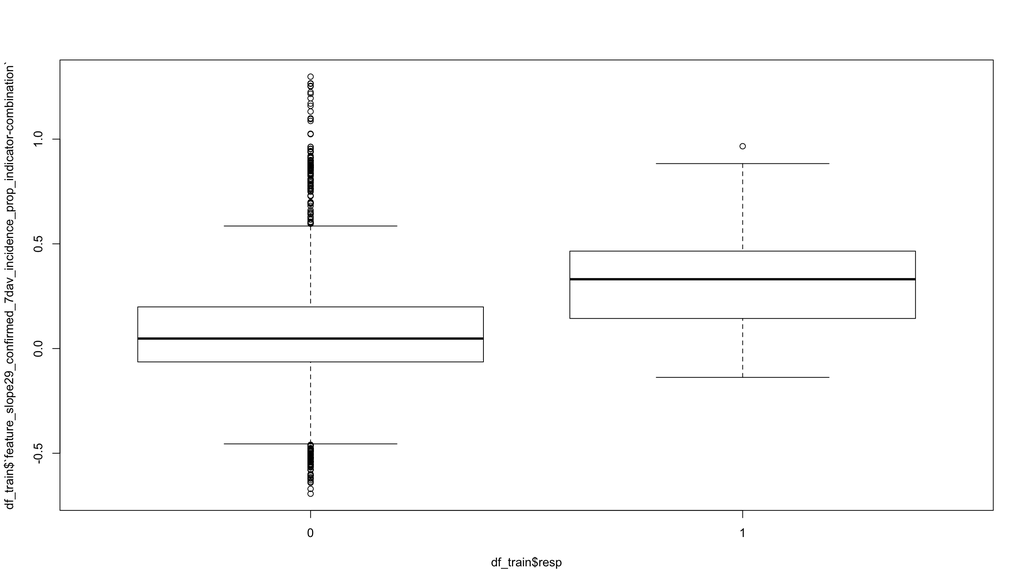

```r
boxplot(df_train$`feature_slope29_confirmed_7dav_incidence_prop_indicator-combination`~df_train$resp)
```

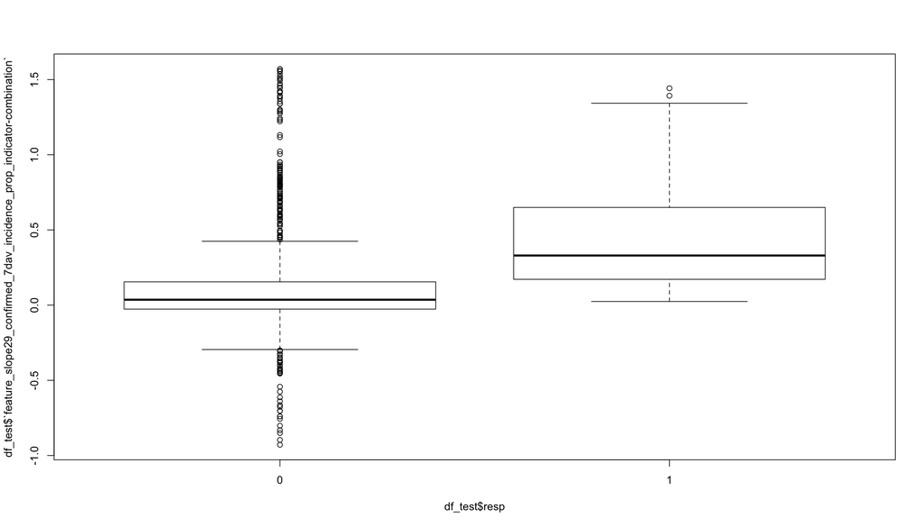

```r
boxplot(df_test$`feature_slope29_confirmed_7dav_incidence_prop_indicator-combination`~df_test$resp)
```

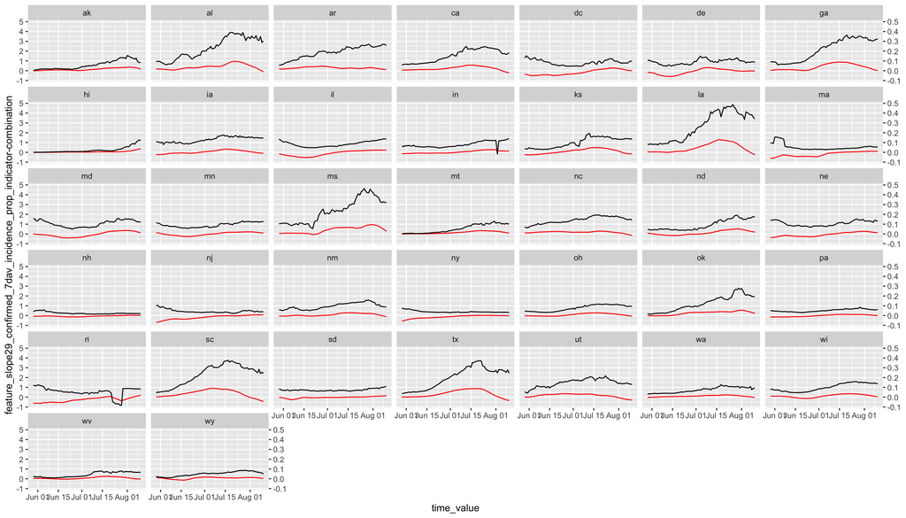

```r
ggplot(df_train, aes(x = time_value, y = `feature_slope29_confirmed_7dav_incidence_prop_indicator-combination`)) +
  geom_line(col = 'red') +
  geom_line(aes(y = `feature_lag0_confirmed_7dav_incidence_prop_indicator-combination`/10)) +
  scale_y_continuous(sec.axis = sec_axis(~./10))+
  facet_wrap(~geo_value)
```

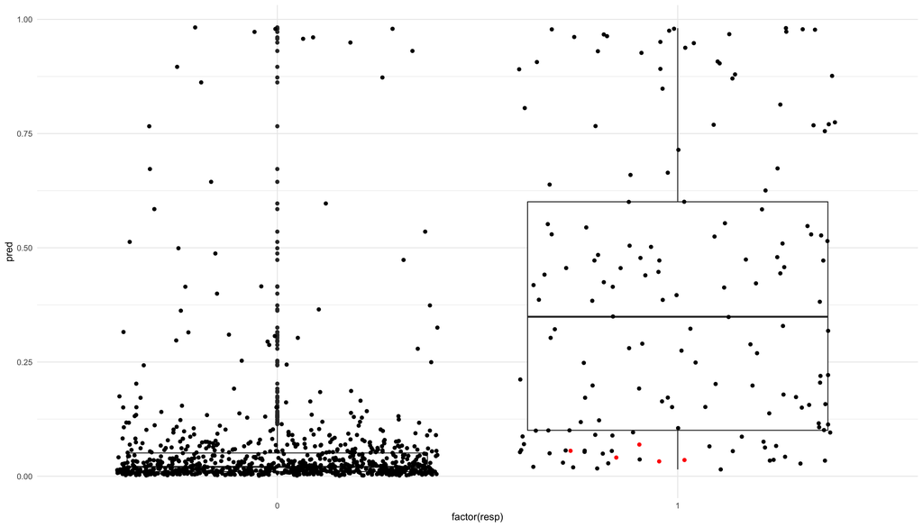

```r
## Obtain the predictions
preds = predict(fit_lasso, s = "lambda.min",
                newx = as.matrix(df_test %>% select(-geo_value, -time_value, -resp)),
                type = "response")[,1]

## ## For comparison: the unregularized logistic regression.
## preds = predict(glmnet(x = as.matrix(df_train %>% select(-geo_value, -time_value, -resp)),
##                        y = df_train$resp,
##                        family = "binomial",
##                        lambda = 0),
##                 newx = as.matrix(df_test %>% select(-geo_value, -time_value, -resp)), type = "response")[,1]

one_after_0 <- function(vec, n = 1){
  out <- rep(NA, length(vec))
  out[1:n] <- "black"
  for(i in (1+n):length(vec)){
    out[i] <- ifelse(all(vec[(i-n):(i-1)] == 0) && (vec[i] == 1), "red", "black")
  }
  return(out)
}

df_aux <- df_test %>% select(geo_value, time_value, resp)
df_aux$pred = preds
df_aux <- plyr::ddply(df_aux, "geo_value", function(df_temp){
  df_temp$color = one_after_0(df_temp$resp)
  return(df_temp)
})
ggplot(df_aux, aes(x = factor(resp), y = pred)) + geom_boxplot() + theme_minimal() + geom_jitter(color = df_aux$color)
```

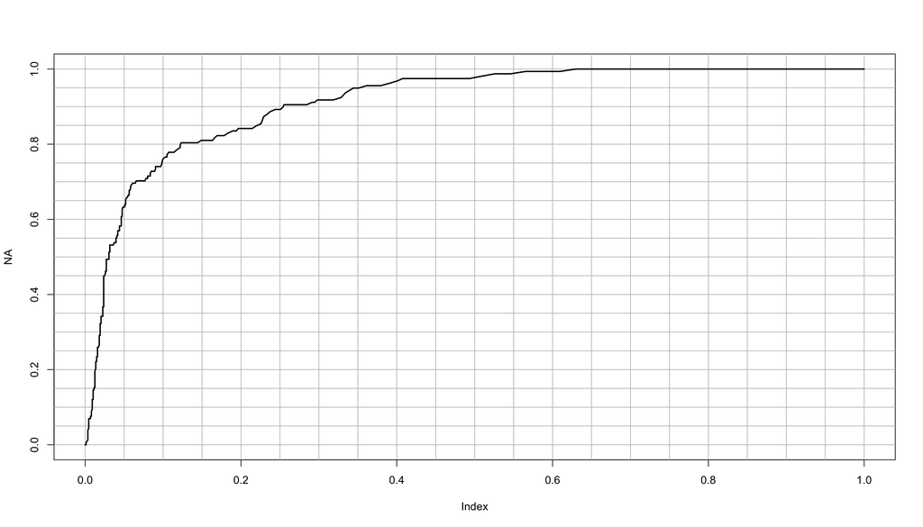

```r
## See predictions against truth
predictions <- df_test %>% select(geo_value, time_value, resp) ## these are the real
real_labels = predictions %>% select(resp) %>% unlist()
metrics <- lapply(seq(0, 1, 0.001), function(cutoff){
  logreg_preds = (preds > cutoff)
  return(c(cutoff = cutoff,
           fpr = sum((real_labels==1) & (logreg_preds==1)) / sum((real_labels==1)),
           fnr = sum((real_labels==0) & (logreg_preds==1)) / sum((real_labels==0))))
})
metrics <- do.call(rbind, metrics) %>% as_tibble()
plot(NA, ylim=c(0,1), xlim=c(0,1))
abline(v=seq(from=0,to=1, by = 0.05), col='grey')
abline(h=seq(from=0,to=1, by = 0.05), col='grey')
lines(metrics$fpr ~ metrics$fnr, type='l', lwd=2)
```

```r
preds <- fit_logistic_regression(df_train, df_test, nfold = 5, alpha = 1, geo_cv_split_seed = geo_cv_split_seed )
predictions[[paste("lasso_lags", lags, "_nahead", n_ahead, sep = "")]] = preds
```

## Diagnostics

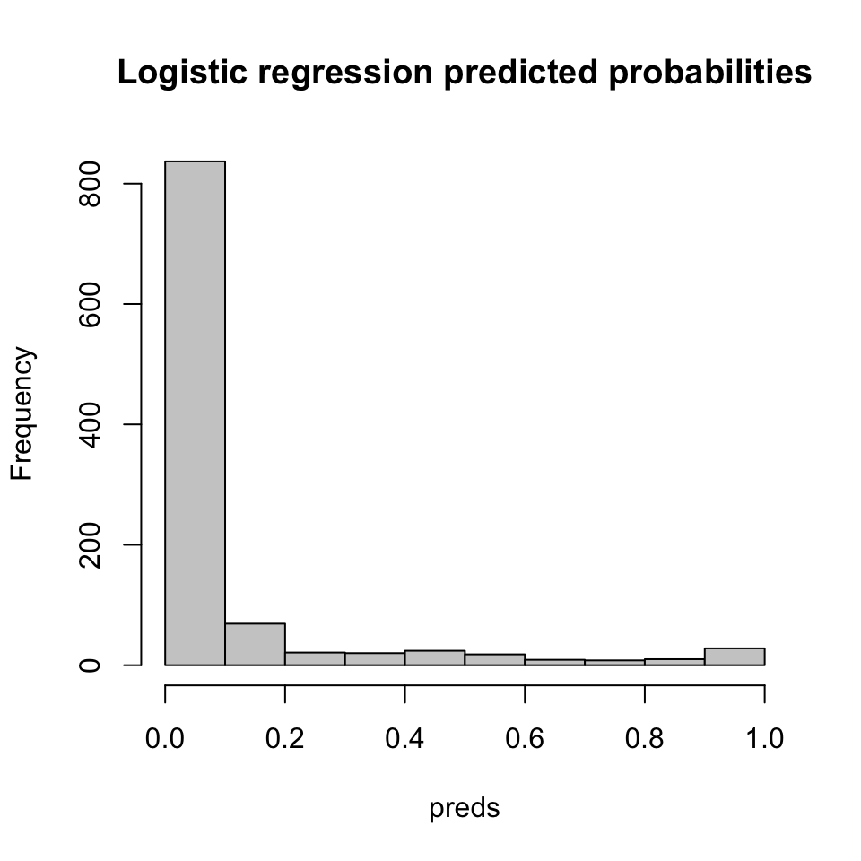

```r
hist(preds, col='grey80', main="Logistic regression predicted probabilities")
```

The predictions are great:

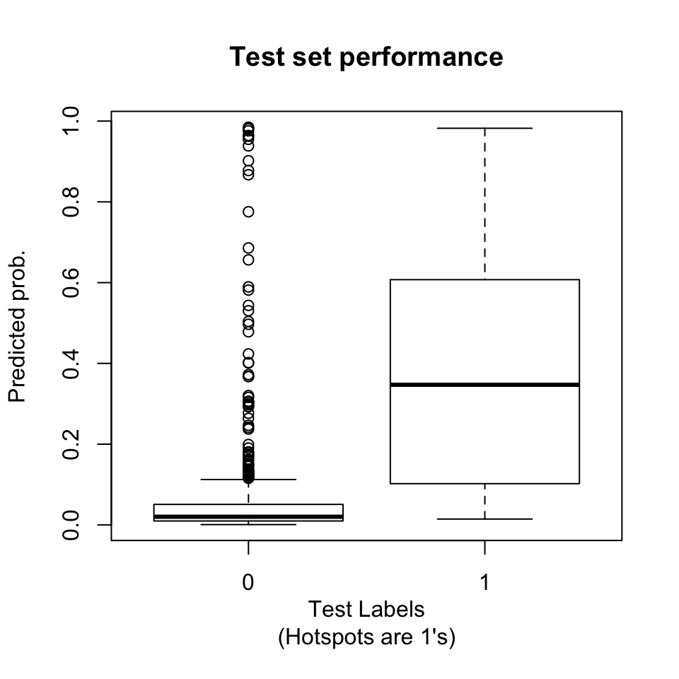

```r
testmat = cbind(preds=preds, resp= df_test$resp) %>% as_tibble()
res = list("0" = testmat %>% subset(resp==0) %>% select(preds) %>% unlist(),
           "1" = testmat %>% subset(resp==1) %>% select(preds) %>% unlist())
boxplot(res, xlab = "Test Labels\n(Hotspots are 1's)",
        ylab = "Predicted prob.",
        main = "Test set performance")
```

Let’s see predicted probabilities (thick green lines) overlaid with the JHU case counts (red points are hot spots).

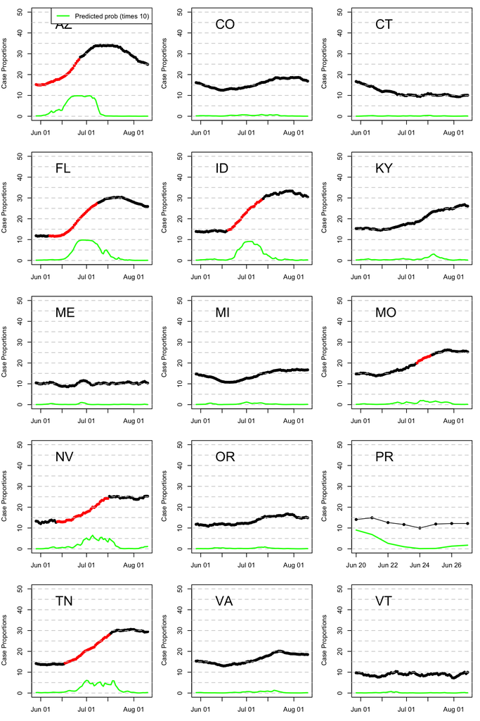

## Tentative conclusions

- Before, when we were splitting CV folds by consecutive time blocks before; now we are splitting by geo values (states).
- Now, we are aligning our CV scheme to be the same as our training/test split scheme (all by geo).
- We might be making the task too easy for ourselves, because we can see future time points in other states when training.
- It’s possible that if we know full trajectories from some states, predicting rises in other states is an easy task.
- Put differently, it’s possible that our “out-of-geo” performance looks good now, but when we look to predict new rises in the future, we won’t have access to other states’ full data trajectories, and we won’t be able to detect hotspots well. It’s more likely that all the rises will be happening together.